# 都市の利益1

規模の経済と企業城下町

岩田真一郎（神奈川大学経済学部）

2026-03-06作成，2026-03-06改訂

［PDF形式：326KB］

企業は生産した財やサービスを市場を通じて消費者や他の企業に供給します．その生産の場は地理的に一様に分布するのではなく，特定の場所に集中することが少なくありません．「なぜ企業はこのように集中して立地するのでしょうか？」この**問い**が，都市経済学の基本的な問いになります．

企業が1箇所に集まるのは，そうすることに何らかの利益があるからだと考えられます．この利益を説明するキーワードの一つが，ミクロ経済学で学ぶ**規模の経済**です．もっとも，規模の経済は個別企業が1つの場所で生産活動を行う利益を説明する概念であり，複数の企業が互い近接して生産活動する利益までは十分に説明しません（金本・藤原，2016）．この利益を説明するキーワード（概念）が都市経済学で頻繁に用いられる**集積の経済**です．本稿では規模の経済を取り上げ，集積の経済については別（都市の利益2）に取り上げます．

# 1 規模の経済

## 1.1 分業の利益

企業の利潤は収入から費用を差し引いたものであるため，利潤を確保するには費用を抑えることが重要です．生産量が与えられている場合，これは

$$平均費用 =\frac{費用}{生産量}$$
を引き下げることに他なりません．

この点を考えるために，工場設備と労働を用いて財を生産する企業の平均費用を考えます．図1に示されるように，企業は1つの工場と2人の労働者を用いて財を生産しているとしましょう．2人の労働者は工場内で作業を行い，8つの工程を経て財が生産されるとします．ここでは，2人がそれぞれ8工程のうち4工程ずつを担当すると考えます．

図1：1工場・2労働体制・1箇所

できあがった生産量を200単位とすると，1人あたりの生産量（**平均生産物**）は100（=200単位／2人）になります．工場の賃貸料が1000，労働者の賃金は1人500の合計1000とすると，費用はそれらの和の2000になります．したがって，平均費用は10（=2000／200単位）です．

ある限られた（一定の）の期間において生産量を拡大したい場合，どのような方法で平均費用を下げられるでしょうか．例えば，工場を2つに増やすことが考えられます．しかし，工場の選定には時間がかかる可能性があります．このように，一定の期間において投入量を変えられない生産要素は**固定的生産要素**とよばれます．したがって，この期間では工場数を増やすことはできません．なお，生産要素の一部が固定的であり，その投入量を変えられない期間を，ミクロ経済学では**短期**とよびます．

次に，労働者を4人増やす場合はどうでしょうか．労働者は募集をかけることで，すばやく採用できる可能性があります．このように，ある一定の期間に投入量を変えられる場合，その生産要素は**可変的生産要素**とよばれます．そこで，図2のように，企業は労働者の増加によって，生産量の増加に対応するとしましょう．このとき，1人あたりの担当は，8工程ある作業を4人で分担することで2工程に減らせます．労働者は担当する作業が減る分，同じ労働時間でも作業に慣れ，生産性の向上が期待できます．これは，平均生産物が以前より増えることを意味します．この利益を**分業の利益**とよびます．[^1]

図2：1工場・4労働体制・1箇所

分業の利益を平均費用面から考えましょう．図2の体制で，生産量が600になったとします．したがって，平均生産物は150（600単位／4人）に増加します．費用は，工場の賃貸料が図1と変わらずに1000のままで，労働者の賃金は合計2000に上昇します．この結果，平均費用は5（3000／600単位）に低下します．

さて，一定の期間を過ぎれば，企業は工場数を増やせるようになります．そうすることで，生産体制を見直し，平均費用をさらに下げられるかもしれません．このように，すべての生産要素の投入量を変えられる期間を，ミクロ経済学では**長期**とよびます．そこで，企業は工場数と労働者数の投入量を調整しながら，600単位を生産する費用（これを**長期費用**といいます）をさらに引き下げられるかを考えます．しかし，これ以上費用を低下させることができないとしましょう．これは，図2の1工場・4労働体制が，600単位を生産する際の長期費用を最小化していることを意味します．このとき，長期平均費用も5になります．

## 1.2 規模に関する収穫一定

しばらく，1工場・4労働体制で600単位を生産していたところ，生産量拡大の機会が巡ってきたとしましょう．企業はすぐ（短期）には工場数を変えられないため，例えば図3のように，労働者を8人に増やすことで対応します．このとき，1人あたりの担当は，8工程ある作業を8人で分担することで1工程に減らせます．そのため，労働者の平均生産物は増加しそうです．しかし，実際には平均生産物が減少したとしましょう．例えば，この体制での生産量が720であったとします．このとき，平均生産物は90（＝720単位／8人）にとどまります．費用は，工場の賃貸料が1000のままですが，労働者の賃金が合計4000に上昇します．したがって，平均費用は約7（＝5000／720単位）に上昇します．

図3：1工場・8労働体制・1箇所

なぜ，平均生産物は順当に増え続けなかったのでしょうか．その理由は固定的生産要素の存在です．工場数を増やせないため，8人全員が同じ工場内で働くことになります．このとき，8人が働くための十分なスペースが確保できないと，工場内が混み合い，作業効率が低下する可能性があります．[^2]例えば，誰かの作業が他の人の作業を妨げるといった状況が生じ，その結果，平均生産物が減少します．

一方，長期では，企業は工場数を増やせるようになります．そこで，図4のように，うり二つの工場をもう1棟借り上げ，4人の労働者をそちらに配置し，各工場で8工程を経て財を完成させるとしましょう．この場合，再び，労働者は1人あたり2工程を分担することになります．これは，図2の体制がもう1つできる，2倍になることを意味します．このため，2つの工場で生産量は2倍の1200になりますが，平均生産物は150（＝1200単位／8人）のままです．費用も2倍の6000になりますが，長期平均費用は5（＝6000／1200単位）で変わりません．

図4：1工場・4労働体制・2箇所

図5は，図2の体制における長期平均費用（5）と生産量（600）の組み合わせA点と図4の体制における長期平均費用（5）と生産量（1200）の組み合わせB点を示しています．この2点を結ぶと，長期平均費用は水平線として描かれます．長期平均費用曲線が水平になるのは，生産要素（工場設備と労働者）を2倍にしても，生産量が2倍にしかならないことを反映しています．このような生産技術は**規模に関して（関する）収穫一定**とよばれます．このとき，生産量を2倍にするには生産要素も2倍必要になるため，費用もちょうど2倍になります．したがって，長期平均費用は一定になります．

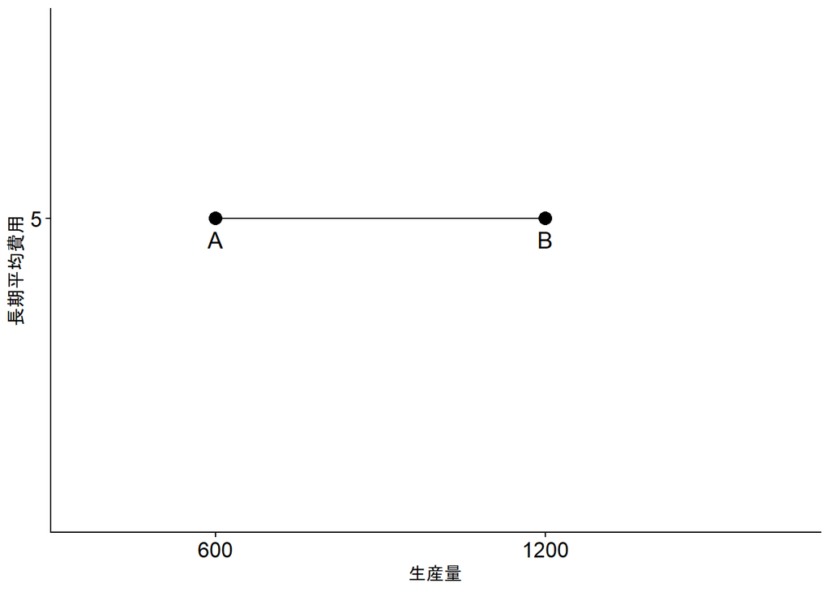

図5：水平な長期平均費用曲線

## 1.3 収穫逓増と規模の経済

図4のように工場を2箇所借りる場合は，工場が離れて描かれており，各工場で労働者は2工程を分担しました．しかし，このような体制ではなく，工場を隣り合わせで2棟借り上げたり，2工場分のスペースをもつ大きな工場を1棟借り上げたりすることで，各労働者の工程を1つに特化させ，生産性を高めることは考えられないでしょうか．そこで，図6は，2工場分に相当する規模の大きな工場を1棟借り，8人全員が同じ工場内で働く体制を描いています．図3とは異なり，工場は8人に対して十分なスペースがあるため，工場規模が制約となって生産性を下げることはありません．すなわち，分業の利益による生産性の上昇だけが現れます．例えば，この体制での生産量が1500であったとします．このとき，平均生産物は187.5（＝1500単位／8人）に増加します．一方，費用は工場の賃貸料が2000（2工場相当）で，労働者の賃金は4000のままです．したがって，平均費用は4（＝6000／1500単位）に低下します．

図6：1大工場（2工場相当）・8労働体制・1箇所

これは，生産要素投入量が等しくても，計算上では図4の体制よりも，図6の体制のほうが費用が低くなることを意味します．その上で，改めて，長期平均費用曲線を描き直してみます．図7は，図2の体制における長期平均費用（5）と生産量（600）の組み合わせA点と図6の体制における長期平均費用（4）と生産量（1500）の組み合わせC点を示しています．この2点を結ぶと，長期平均費用は右下がりとして描かれます．長期平均費用曲線が右下がりになるのは，生産要素（工場設備と労働者）を2倍にすると生産量が2倍より大きくなるからです．このような生産技術は**規模に関して収穫逓増**とよばれます．したがって，2倍の生産量を得るために生産要素を2倍にする必要はなく，費用は2倍未満にとどまります．その結果，長期平均費用が低下します．このように，長期平均費用が生産量とともに下がることを**規模の経済**とよびます．

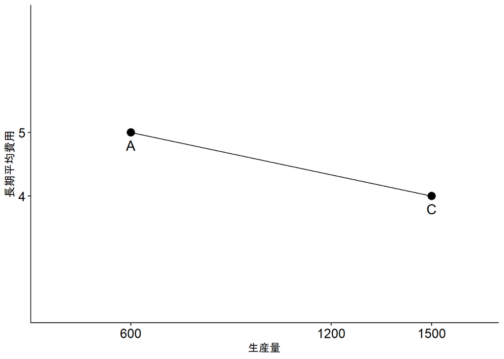

図7：規模の経済

# 2 集中生産の利益

図6のように生産拠点を1箇所に集約する生産体制を集中生産とよび，図4のように生産拠点を2箇所に分散する生産体制を分散生産とよびましょう．果たして，分散生産が費用面で有利になることはないのでしょうか．そこで，いままでとは異なり，労働者の移動費用（交通費）を企業が負担する場合を考えてみましょう．なお，以下の説明は，ブルックナーが紹介したモデルを参考に改訂しています．

労働者は，図4の左から4人目までは左の工場の，右から4人目までは右の工場の近くに住居を構えていると仮定します．そして，近くの工場で働く場合は，労働者は移動費用なしで工場に通えるとします．

ここで，企業が1200単位の財を生産目標としたとしましょう．すると，分散生産の場合，各工場は第1.2節で説明した工場と労働者の組み合わせで600単位ずつ生産し，長期費用の最小化を図ります．このとき，長期平均費用は5であったため，長期費用（6000）は次式から求まります．
$$\underset{\displaystyle \text{（長期平均費用）}}{\displaystyle 5} \times
\underset{\displaystyle \text{（生産量）}}{\displaystyle 600} \times
\underset{\displaystyle \text{（工場数）}}{\displaystyle
2}　\label{d}\tag{1}$$
これが分散生産の際にかかる費用になります．

次に，集中生産で1200単位を生産する場合を改めて考えましょう．第1.3節では，2工場分のスペースをもつ大工場を借り，労働者を2倍にして財を生産しました．規模に関する収穫逓増が働くため，生産量は2倍より多い1500に達しました．したがって，1200単位の財を生産するために，ここまで生産要素を増やす必要はありません．そこで，企業が調べたところ，1200単位を1棟の工場で長期費用を最小化する形で生産する場合は，図8のように，工場のスペースを1.5工場分借り，労働者を7人雇えばよいことがわかったとします．長期費用は工場の賃貸料が1500（1.5工場相当）で，労働者の賃金は3500（7人×500）になります．したがって，長期平均費用は25／6（＝5000／1200単位＝約4.2）になり，規模の経済が働いていることが確認できます．

図8：1大工場（1.5工場相当）・7労働体制・1箇所

しかし，集中生産の際にかかる費用はこれだけではありません．右側の3人が工場と離れて立地しているため，移動費用が発生します．ここで，1人あたりの移動費用をTと表すと，企業が負担する移動費用は合計3T（3人×T）になります．

以上をまとめると，集中生産の際にかかる費用は次式のように表現できます．

$$\underset{\displaystyle \text{（長期平均費用）}}{\displaystyle
\frac{25}{6}} \times
\underset{\displaystyle \text{（生産量）}}{\displaystyle 1200} \times
\underset{\displaystyle \text{（工場数）}}{\displaystyle 1}
+\underset{\displaystyle \text{（移動費用）}}{\displaystyle
3T}　\label{c}\tag{2}$$

（$\ref{d}$）式から（$\ref{c}$）を差し引いたときに，それがゼロより大きいと，分散生産が費用面で劣り，集中生産が優れていることになります．そこで，この関係を満たすように，（$\ref{d}$）式から（$\ref{c}$）を差し引くと（$\ref{sem}$）式が得られます．

$$\underset{\displaystyle \text{（集中生産の利益）}}{\displaystyle \left(5
- \frac{25}{6}\right)} \times
\underset{\displaystyle \text{（生産量）}}{\displaystyle 1200} >
\underset{\displaystyle \text{（移動費用）}}{\displaystyle 3T}
\label{sem}\tag{3}$$
（$\ref{sem}$）式は，生産量が与えられている状況で，集中生産が費用面で有利になる条件を示しています．（$\ref{sem}$）式左辺の集中生産の利益は，生産量を等しくしたときの，生産体制の差に伴う長期平均費用の差を表しており，規模の経済からその差は正（プラス）になります．したがって，集中生産の利益とは規模の経済から生じる利益に他なりません．

（$\ref{sem}$）式を整理すると，（$\ref{T}$）式を得ます．

$$\frac{1000}{3} > \underset{\displaystyle
\text{（1人あたり移動費用）}}{\displaystyle T} \label{T}\tag{4}$$

（$\ref{T}$）式は，1人あたり移動費用が約333よりも低いとき，集中生産が費用面で有利になることを教えてくれます．逆に，1人あたり移動費用が約333よりも高いとき，分散生産が費用面で有利になります．

# 3 企業城下町

これまでの理論的な説明を踏まえて，現実の都市の事例へと話を展開していきましょう．大量生産には，規模の経済を活かした集中生産が有利になります．実際に，（$\ref{sem}$）式から，目標とする生産量が大きくなるほど，（$\ref{sem}$）式が成立しやすくなることがわかります．また，移動費用の低下も（$\ref{sem}$）式を成立しやすくします．全国各地で進められた（高速）道路や（高速）鉄道の整備は，移動費用を低下させ，集中生産を促した可能性を示唆します．

1つの企業の工場規模が大きくなるにつれ，工場の近くや交通網でつながった地域に住む労働者が増えます．その結果，労働者の生活を支える教育施設や医療施設，商業施設が整備され，教育，医療，商業サービスを提供する新たな雇用も生まれます．さらに，この企業を支える下請企業も進出してくることが期待されます．こうした経済活動の拡大に伴い，地域の税収も増え，社会資本の整備も進むでしょう．このようにして，この企業を中心とする**[企業城下町](https://ja.wikipedia.org/wiki/%E4%BC%81%E6%A5%AD%E5%9F%8E%E4%B8%8B%E7%94%BA)**のような都市が形成されることになります．企業城下町の例としては，トヨタ自動車の愛知県豊田市や田原市，SUBARUの群馬県太田市や大泉町などが挙げられます．

しかし，これらの都市や地域名から大都市を想像することは難しいでしょう．規模の経済を活用した企業城下町は，1つの企業を中心に形成された都市です．したがって，複数の企業が集積する大都市の形成を説明することはできません（金本・藤原，2016）．

また，企業城下町は確かに雇用を生み出しますが，一旦中心企業である「城主」の業績が悪化すると，町全体の雇用に大きな影響が出る危険性が指摘されます．実際，そのような事例がニュースでもよく伝えられています．例えば，吉田・沖永・落合（2022）は，和歌山県有田市の雇用を支えてきたENEOS和歌山製油所の閉鎖に伴う地元の翻弄ぶりを伝えています．河野・旭（2026）によると，ENEOSはその後，和歌山製造所の敷地内に再生航空燃料（SAF）の生産拠点を整備することで地元の理解を得たものの，石油精製並みの経済規模を保つことは難しく，従来通りの雇用や税収の維持に対して疑問を投げかけています．

最後に，企業城下町の「城主」の業績悪化に対する下請企業の対応例を見てみましょう．日産は，神奈川県横須賀市の追浜工場での車両生産を2027年度末に終了し，日産自動車九州（福岡県苅田町）へ生産拠点を移すと発表しました．これにより，雇用の維持や取引企業への影響が懸念されています．しかし，宗像ら（2025）によると，過度な悲観の声はあまり聞かれないそうです．というのも，それ以前から日産の合理化策に耐えかねて脱・日産を進めた多くの取引企業が，自動車で培った技術をさらに磨き，自動車以外の新しい販路にも挑戦してきたからです．そして，地元企業の中には，日産の人員整理に対して，自ら雇用の受け皿になる企業も現れているようです．[^3]

# 4 テキストガイド

本稿はミクロ経済学の規模に関する収穫逓増や規模の経済の概念を応用して企業城下町が誕生する要因を考えました．規模に関する収穫逓増や規模の経済については，下記のミクロ経済学のテキストが参考になります．

- スティーヴン・レヴィット, オースタン・グールズビー, チャド・サイヴァーソン（安田洋祐監訳・高遠裕子訳）（2017）[『レヴィット ミクロ経済学 基礎編』](https://book.toyokeizai.net/textbook/book/?translated%5B%5D=translate4&s=&open=112)東洋経済新報社

このテキストの第7章では，生産過程における規模に関する収穫（逓増・一定・逓減）と，それを費用面から見た規模の経済・不経済との関係を詳しく説明しています．

規模の経済と企業城下町の関係については，例えば次のテキストや新書が参考になります．

- 高橋孝明（2012）[『都市経済学』](http://www.yuhikaku.co.jp/books/detail/9784641184060)有斐閣ブックス
- 山本和博（2022）[『大都市はどうやってできるのか』](https://www.chikumashobo.co.jp/product/9784480684356/)ちくまプリマー新書411，筑摩書房

本稿における規模の経済と移動費用の関係に基づく集中生産の利益の説明は，次のテキストの第1章に大きく依拠しています．

- Brueckner, Jan K（2011）[*Lectures on Urban Economics*](https://mitpress.mit.edu/9780262016360/lectures-on-urban-economics/), MIT Press

このテキストでは，労働者の移動費用ではなく，生産した財を離れた地域に運ぶ輸送費用を考慮し，集中生産か，分散生産かを議論しています．

# 参考文献

- 金本良嗣・藤原徹（2016）[『都市経済学（第2版）』](https://str.toyokeizai.net/books/9784492813034/)＜プログレッシブ経済学シリーズ＞東洋経済新報社．↩︎
- 河野真央・旭泰世（2026）[「出光が製油所維持，地域経済への恩恵大きく 脱炭素への移行は難航」](https://www.nikkei.com/article/DGXZQOUC278JP0X20C26A2000000/)『日本経済新聞』2026年2月28日．↩︎
- 竹内紘雅（2026）[「閉鎖30年の日産座間工場，跡地はイオンや物流拠点 市税収入は2割増 変わる「日産の街」㊤」](https://www.nikkei.com/article/DGXZQOCC197RA0Z10C26A2000000/)『日本経済新聞』2026年3月3日．↩︎
- 宗像藍子・田中健斗・松原礼奈・竹内紘雅・松原三佐子・藤沢愛・富田美緒（2025）[「もう「日産城下町」ではない 追浜工場停止，地元の本音は」](https://www.nikkei.com/telling/DGXZTS00016680W5A620C2000000/)『日本経済新聞』2025年7月17日．↩︎
- 吉田貴・沖永翔也・落合修平（2022）[「製油所・石化・高炉の選択 レガシーは変身か閉鎖か」](https://www.nikkei.com/article/DGXZQOUB103CV0Q2A810C2000000/)『日経ヴェリタス』2022年8月28日号．↩︎
- Brueckner, Jan K（2011）[*Lectures on Urban Economics*](https://mitpress.mit.edu/9780262016360/lectures-on-urban-economics/), MIT Press.↩︎

# R環境

**セッション情報**

- R version 4.5.2
  - RStudio 2026.01.1+403
  - rmarkdown 2.30

**使用したパッケージ**

- `tidyverse`

# リンク

[都市経済学講義ノート](https://shinichiro-iwata.github.io/lecture-notes-urban-econ/)

[Rによる地理空間データの可視化](https://shinichiro-iwata.github.io/geospatial-data-visualization/)

[Shinichiro Iwata](https://shinichiro-iwata.github.io/)

**アイコン**

Font Awesome 7.0.0

**生成AIの使用について**

ChatGPTのサービスを利用した後，内容を確認し，必要に応じて編集を行いました．

[^1]: これは，**特化の利益**とも考えられます．分業が進むと，各労働者が特定の工程に特化するため，生産性が高まります．
[^2]: ミクロ経済学では，工場規模が変えられないとき，労働の限界生産物が逓減することを学びます．労働の限界生産物が逓減すると，平均生産物も低下する性質があります．
[^3]: 神奈川県座間市もかつては日産の企業城下町でしたが，1995年に工場が閉鎖しました．しかし，「地の利」が活きて，町は衰退することはありませんでした．竹内（2026）によると，工場跡地は高速道路や幹線道路に近く，その地の利を生かして物流企業の倉庫や大型商業施設が相次いで進出しました．さらに，東京都内や横浜市へのアクセスの良さからベッドタウンとして人口が増えたことも加わり，むしろ一定の活力を保ったと報告しています．